# Bucks Hackathon Prompt 2

# Milwaukee Bucks Fan Engagement & Customer Journey Analysis

## Objective

Analyze fan behaviors to optimize engagement, ticketing strategies, and long-term retention by understanding the customer lifetime journey.

## 1. Map the Customer Journey Stages

Define customer segments based on historical purchasing behavior:

- **Casual Fan**: Buys single-game tickets occasionally.
- **Engaged Fan**: Purchases multiple single-game tickets or group tickets.
- **Partial Plan Holder**: Purchases partial plan packages.
- **Season Ticket Prospect**: Has engaged at a high level but hasn’t committed to full season tickets.
- **Season Ticket Member (STM)**: Highest level of commitment.

**Tasks:**

- Segment customers based on historical behaviors.
- Identify transition probabilities between these stages over time.

## 2. Analyze Key Drivers of Engagement & Retention

Use historical ticketing, spending, and engagement data to uncover:

- What behaviors lead to fans moving to a higher tier?
  - (e.g., What % of Casual Fans convert to Partial Plan Holders?)
- What indicators show churn risk?
  - (e.g., Inactivity, drop in spending, low digital engagement)

## 3. Build Predictive Models

- **Propensity Model**: Predict likelihood of fans progressing to the next engagement tier.
- **Churn Model**: Predict risk of disengagement or cancellation.

## 4. Provide Business Insights & Recommendations

- Suggest data-driven marketing and retention strategies:
  - Targeted offers
  - Email campaigns
  - Upsell promotions
- Propose engagement initiatives to increase Customer Lifetime Value (CLV):
  - Loyalty programs
  - Exclusive content
  - Personalized experiences

```python
import pandas as pd
import csv
from subprocess import check_output
import os
# new import statements
import zipfile
from io import TextIOWrapper
import matplotlib.pyplot as plt
from sklearn.cluster import KMeans
from sklearn.metrics import confusion_matrix, ConfusionMatrixDisplay, classification_report
from sklearn.model_selection import train_test_split
from sklearn.pipeline import Pipeline
from sklearn.preprocessing import StandardScaler
from sklearn.linear_model import LogisticRegression
from sklearn.ensemble import RandomForestClassifier
from sklearn.metrics import roc_auc_score, classification_report, precision_recall_fscore_support
```

```python
folder_path = 'Bucks_Hackathon_2025 - Copy/Hackathon Prompt 2 Data'
csv_files = [os.path.join(folder_path, f) for f in os.listdir(folder_path) if f.endswith('.csv')]
csv_files
```

```
['Bucks_Hackathon_2025 - Copy/Hackathon Prompt 2 Data\\Prompt2Demographics.csv',
 'Bucks_Hackathon_2025 - Copy/Hackathon Prompt 2 Data\\Prompt2F&B.csv',
 'Bucks_Hackathon_2025 - Copy/Hackathon Prompt 2 Data\\Prompt2Retail.csv',
 'Bucks_Hackathon_2025 - Copy/Hackathon Prompt 2 Data\\Prompt2Tickets.csv']
```

## Import the provided data, look at data frames

```python
demographics = pd.read_csv('Bucks_Hackathon_2025 - Copy/Hackathon Prompt 2 Data\\Prompt2Demographics.csv')
food_and_beverage = pd.read_csv('Bucks_Hackathon_2025 - Copy/Hackathon Prompt 2 Data\\Prompt2F&B.csv')
retail = pd.read_csv('Bucks_Hackathon_2025 - Copy/Hackathon Prompt 2 Data\\Prompt2Retail.csv')
ticket_sales = pd.read_csv('Bucks_Hackathon_2025 - Copy/Hackathon Prompt 2 Data\\Prompt2Tickets.csv')
```

```python
ticket_sales
```

|  | AccountNumber | SeasonKey | PurchaseDate | MasterEventName | ProductType | ProductGroup | InventoryCount | InventoryNetAmount | ScannedFlag |
| --- | --- | --- | --- | --- | --- | --- | --- | --- | --- |
| 0 | 57377 | 2023 | 3/20/2024 | 2024-03-21 Brooklyn Nets | Single Game | Single Game | 1 | 10.8 | 1 |
| 1 | 37624 | 2018 | 5/30/2018 | 2019-02-21 Boston Celtics | New Full | Full Season | 1 | 22.5 | 1 |
| 2 | 13361 | 2023 | 3/7/2023 | 2024-03-21 Brooklyn Nets | Renewal Full | Full Season | 1 | 1750.5 | 0 |
| 3 | 42161 | 2018 | 5/29/2018 | 2018-11-14 Memphis Grizzlies | New Full | Full Season | 1 | 22.5 | 1 |
| 4 | 42161 | 2018 | 5/29/2018 | 2018-12-05 Detroit Pistons | New Full | Full Season | 1 | 22.5 | 1 |
| ... | ... | ... | ... | ... | ... | ... | ... | ... | ... |
| 1048570 | 79618 | 2022 | 8/15/2022 | 2022-10-26 Brooklyn Nets | Renewal Full | Full Season | 1 | 77.4 | 1 |
| 1048571 | 82974 | 2022 | 1/13/2022 | 2022-10-28 New York Knicks | Renewal Full | Full Season | 1 | 1665.0 | 1 |
| 1048572 | 65187 | 2022 | 1/13/2022 | 2022-10-28 New York Knicks | Renewal Full | Full Season | 1 | 106.2 | 1 |
| 1048573 | 54336 | 2022 | 2/2/2022 | 2022-10-31 Detroit Pistons | Renewal Full | Full Season | 1 | 157.5 | 1 |
| 1048574 | 33405 | 2022 | 1/13/2022 | 2022-10-29 Atlanta Hawks | Renewal Full | Full Season | 1 | 77.4 | 0 |

1048575 rows × 9 columns

```python
food_and_beverage.sort_values(by="AccountNumber")
```

|  | AccountNumber | GuestCheckID | PurchaseDate | RevenueCenterName | ReportLineQuantity | ReportLineAmount |
| --- | --- | --- | --- | --- | --- | --- |
| 0 | 3 | 258676055 | 10/31/2021 | Section 106 Pickup | 3 | 31.99 |
| 1 | 7 | 270397682 | 1/19/2022 | Section 221 Pickup | 4 | 9.00 |
| 2 | 7 | 270397682 | 1/19/2022 | Section 221 Pickup | 4 | 2.20 |
| 3 | 7 | 270397682 | 1/19/2022 | Section 221 Pickup | 4 | 9.00 |
| 4 | 7 | 270397682 | 1/19/2022 | Section 221 Pickup | 4 | 9.00 |
| ... | ... | ... | ... | ... | ... | ... |
| 115535 | 125783 | 268654847 | 1/3/2022 | Section 221 Pickup | 7 | 9.00 |
| 115536 | 125783 | 268654847 | 1/3/2022 | Section 221 Pickup | 7 | 9.00 |
| 115539 | 125783 | 268654847 | 1/3/2022 | Section 221 Pickup | 7 | 9.00 |
| 115540 | 125786 | 331430833 | 10/29/2022 | Section 108 PIZZA Pickup | 3 | 25.78 |
| 115541 | 125786 | 347112370 | 1/17/2023 | Section 106 MECCA BURGER Pickup | 4 | 53.42 |

115542 rows × 6 columns

```python
retail.sort_values(by="AccountNumber")
```

|  | AccountNumber | OrderID | PurchaseDate | LineItemQuantity | LineItemTotalPrice | ProductTitle | CategoryName |
| --- | --- | --- | --- | --- | --- | --- | --- |
| 0 | 5 | 4.930000e+12 | 10/1/2023 | 1 | 117.0 | Nike 2022 Icon Edition Damian Lillard Milwauke... | Jersey |
| 1 | 9 | 3.870000e+12 | 7/22/2021 | 1 | 27.0 | Fanatics Ankle Breaker Icon 2021 NBA Champions... | T-Shirt |
| 2 | 9 | 3.870000e+12 | 7/22/2021 | 1 | 25.2 | '47 Brand 2021 NBA Champions Clean Up Charcoal... | Hat |
| 3 | 23 | 7.480000e+11 | 12/7/2018 | 1 | 22.5 | New Era Camo Icon Milwaukee Bucks Adjustable Cap | Hat |
| 4 | 32 | 4.020000e+12 | 11/5/2021 | 1 | 54.0 | Antigua Inspire 2021 NBA Champions Milwaukee B... | T-Shirt |
| ... | ... | ... | ... | ... | ... | ... | ... |
| 62643 | 125764 | 4.700000e+12 | 3/13/2023 | 1 | 57.6 | Big & Tall Fanatics Zipper Pockets Milwaukee B... | Outerwear |
| 62644 | 125768 | 3.840000e+12 | 7/3/2021 | 1 | 22.5 | Item of the Game Bold Icon 2021 NBA Finals Mil... | T-Shirt |
| 62646 | 125786 | 3.840000e+12 | 7/5/2021 | 1 | 22.5 | Item of the Game Hoop Logoman Icon 2021 NBA Fi... | T-Shirt |
| 62645 | 125786 | 3.840000e+12 | 7/3/2021 | 1 | 31.5 | Fanatics 2021 Eastern Conference Finals Champs... | T-Shirt |
| 62647 | 125786 | 5.090000e+12 | 1/29/2024 | 1 | 72.0 | Homage HWC '68 Grey Milwaukee Bucks Hooded Swe... | Outerwear |

62648 rows × 7 columns

```python
demographics.sort_values(by="AccountNumber")
```

|  | AccountNumber | DistanceToArena | FinancialScore | Gender | MaritalStatus | PresenceOfChildren | CurrentTier |
| --- | --- | --- | --- | --- | --- | --- | --- |
| 90411 | 1 | 92.0 | 829.0 | Female | Married | Y | 5 |
| 39584 | 2 | 12.0 | 492.0 | NaN | Married | N | 6 |
| 70562 | 3 | 824.0 | 612.0 | Male | Inferred Single | Y | 6 |
| 69416 | 4 | 76.0 | 1000.0 | Male | Inferred Single | Y | 6 |
| 120265 | 5 | 18.0 | 922.0 | Male | Married | Y | 5 |
| ... | ... | ... | ... | ... | ... | ... | ... |
| 10737 | 125783 | 6.0 | 688.0 | NaN | Married | Y | 6 |
| 93531 | 125784 | 70.0 | 297.0 | Male | Inferred Single | N | 6 |
| 82002 | 125785 | 308.0 | 441.0 | Male | Single | Y | 6 |
| 68473 | 125786 | 4.0 | 529.0 | Male | Married | Y | 5 |
| 119342 | 125787 | 630.0 | 945.0 | Female | Single | Y | 5 |

125793 rows × 7 columns

## Approach

Each dataset provides an `AccountNumber`, which will be used for tracking the same account across datasets. Because I want to analyze the movement of fans to and from different engagement levels, I assign each row its appropriate `SeasonKey`. Indicators of fan engagement include food and beverage spending, merchandise purchases, and, of course, ticket sales, so I summarize this information in the `customer_summary` data frame.

```python
def assign_season_key(date):
    # make sure it's a datetime
    date = pd.to_datetime(date)
    year = date.year
    month = date.month

    # Example: NBA season starts in Oct
    if month >= 10:
        return f"{year}-{year+1}"
    else:
        return f"{year-1}-{year}"

# Apply to retail and fnb dataframes
retail["PurchaseDate"] = pd.to_datetime(retail["PurchaseDate"])
retail["SeasonKey"] = retail["PurchaseDate"].apply(assign_season_key)

food_and_beverage["PurchaseDate"] = pd.to_datetime(food_and_beverage["PurchaseDate"])
food_and_beverage["SeasonKey"] = food_and_beverage["PurchaseDate"].apply(assign_season_key)
food_and_beverage
```

|  | AccountNumber | GuestCheckID | PurchaseDate | RevenueCenterName | ReportLineQuantity | ReportLineAmount | SeasonKey |
| --- | --- | --- | --- | --- | --- | --- | --- |
| 0 | 3 | 258676055 | 2021-10-31 | Section 106 Pickup | 3 | 31.99 | 2021-2022 |
| 1 | 7 | 270397682 | 2022-01-19 | Section 221 Pickup | 4 | 9.00 | 2021-2022 |
| 2 | 7 | 270397682 | 2022-01-19 | Section 221 Pickup | 4 | 2.20 | 2021-2022 |
| 3 | 7 | 270397682 | 2022-01-19 | Section 221 Pickup | 4 | 9.00 | 2021-2022 |
| 4 | 7 | 270397682 | 2022-01-19 | Section 221 Pickup | 4 | 9.00 | 2021-2022 |
| ... | ... | ... | ... | ... | ... | ... | ... |
| 115537 | 125783 | 268654847 | 2022-01-03 | Section 221 Pickup | 7 | 9.00 | 2021-2022 |
| 115538 | 125783 | 268654847 | 2022-01-03 | Section 221 Pickup | 7 | 6.99 | 2021-2022 |
| 115539 | 125783 | 268654847 | 2022-01-03 | Section 221 Pickup | 7 | 9.00 | 2021-2022 |
| 115540 | 125786 | 331430833 | 2022-10-29 | Section 108 PIZZA Pickup | 3 | 25.78 | 2022-2023 |
| 115541 | 125786 | 347112370 | 2023-01-17 | Section 106 MECCA BURGER Pickup | 4 | 53.42 | 2022-2023 |

115542 rows × 7 columns

```python
retail_summary = (retail.groupby("AccountNumber").agg(amount_of_purchases=("LineItemTotalPrice", "count"),total_spent=("LineItemTotalPrice", "sum")).reset_index())
retail_summary
```

|  | AccountNumber | amount_of_purchases | total_spent |
| --- | --- | --- | --- |
| 0 | 5 | 1 | 117.00 |
| 1 | 9 | 2 | 52.20 |
| 2 | 23 | 1 | 22.50 |
| 3 | 32 | 4 | 148.50 |
| 4 | 40 | 5 | 250.20 |
| ... | ... | ... | ... |
| 15468 | 125748 | 1 | 14.40 |
| 15469 | 125759 | 7 | 579.60 |
| 15470 | 125764 | 3 | 85.05 |
| 15471 | 125768 | 1 | 22.50 |
| 15472 | 125786 | 3 | 126.00 |

15473 rows × 3 columns

```python
pd.merge(demographics[["AccountNumber","CurrentTier"]], retail_summary, on='AccountNumber')
```

|  | AccountNumber | CurrentTier | amount_of_purchases | total_spent |
| --- | --- | --- | --- | --- |
| 0 | 77503 | 6 | 1 | 31.50 |
| 1 | 44753 | 3 | 2 | 51.30 |
| 2 | 82889 | 6 | 2 | 45.00 |
| 3 | 72603 | 1 | 10 | 194.40 |
| 4 | 31807 | 6 | 24 | 1064.70 |
| ... | ... | ... | ... | ... |
| 15473 | 2562 | 6 | 2 | 117.00 |
| 15474 | 91672 | 6 | 1 | 27.00 |
| 15475 | 38321 | 4 | 1 | 13.46 |
| 15476 | 115499 | 6 | 3 | 160.20 |
| 15477 | 42589 | 5 | 15 | 67.50 |

15478 rows × 4 columns

```python
# Ticket purchase summary
ticket_summary = (
    ticket_sales.groupby("AccountNumber")
    .agg(
        total_tickets=("InventoryCount", "sum"),
        total_ticket_spend=("InventoryNetAmount", "sum"),
        n_purchases=("PurchaseDate", "count"),
        product_types=("ProductType", lambda x: list(x.unique()))
    )
)

# Retail + food/beverage summaries
retail_summary = retail.groupby("AccountNumber")["LineItemTotalPrice"].sum().rename("retail_spend")
fnb_summary = food_and_beverage.groupby("AccountNumber")["ReportLineAmount"].sum().rename("fnb_spend")

# Merge into one customer view
customer_summary = (
    ticket_summary
    .join(retail_summary, how="outer")
    .join(fnb_summary, how="outer")
    .fillna(0)
)
customer_summary
```

| AccountNumber | total_tickets | total_ticket_spend | n_purchases | product_types | retail_spend | fnb_spend |
| --- | --- | --- | --- | --- | --- | --- |
| 3 | 1.0 | 79.2 | 1.0 | [Single Game] | 0.0 | 31.99 |
| 5 | 0.0 | 0.0 | 0.0 | 0 | 117.0 | 0.00 |
| 6 | 37.0 | 2416.5 | 37.0 | [Half Plans, Single Game, Flex Plans] | 0.0 | 0.00 |
| 7 | 7.0 | 86.4 | 7.0 | [Single Game] | 0.0 | 38.20 |
| 9 | 1.0 | 30.6 | 1.0 | [Single Game] | 52.2 | 0.00 |
| ... | ... | ... | ... | ... | ... | ... |
| 125773 | 1.0 | 72.0 | 1.0 | [Single Game] | 0.0 | 0.00 |
| 125774 | 1.0 | 172.8 | 1.0 | [Single Game] | 0.0 | 0.00 |
| 125780 | 0.0 | 0.0 | 0.0 | 0 | 0.0 | 33.43 |
| 125783 | 0.0 | 0.0 | 0.0 | 0 | 0.0 | 42.99 |
| 125786 | 0.0 | 0.0 | 0.0 | 0 | 126.0 | 79.20 |

81534 rows × 6 columns

```python
plans_dict={}
for lst in customer_summary["product_types"]:
    if lst==0:
        continue
    else:
        for plan in lst:
            if plan not in plans_dict:
                plans_dict[plan]=1
            else:
                plans_dict[plan]+=1
```

## Summary of ticket plan purchases

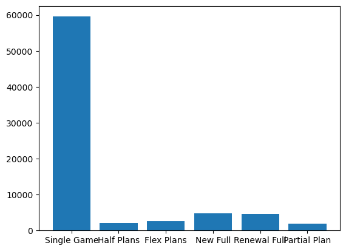

```python
plt.bar(plans_dict.keys(), plans_dict.values())
plt.show()
```

## Assign stages based on purchasing data

These data include an `AccountNumber`'s `stage` in the current `SeasonKey`. This allows me to identify the movement stage by stage from season to season.

```python
def assign_stage(row):
    products = row["product_types"]

    if products == 0:
        return "Casual Fan"
    elif 'Renewal Full' in products or 'New Full' in products:
        return "STM"
    elif "Partial Plan" in products  or 'Half Plans' in products or 'Flex Plans' in products:
        # could analyze more advanced stats about what are current STMs spending on retail and other stuff that would help indicate how perspective members are similar
        if row["retail_spend"] > 100 and row["n_purchases"] > 25:
            return "Season Ticket Prospect"
        else:
            return "Partial Plan Holder"
    elif row["n_purchases"] > 3:  # multiple single-game/group purchases
        return "Engaged Fan"
    elif row["n_purchases"] > 0:
        return "Casual Fan"
    #elif row["n_purchases"]<=1 and row["retail_spend"]==0:
        #return "Lapsed Fan"
    else:
        return "Season Ticket Prospect"  # engaged in other ways but no ticket history

customer_summary["stage"] = customer_summary.apply(assign_stage, axis=1)
```

```python
# Build per-account per-season summary
def assign_stage_season(ticket_df, retail_df):
    # Summarize tickets
    ticket_summary = (
        ticket_df.groupby(["AccountNumber", "SeasonKey"])
        .agg(
            n_purchases=("PurchaseDate", "count"),
            product_types=("ProductType", lambda x: list(x.unique()))
        )
    )
    # Summarize retail
    retail_summary = (
        retail_df.groupby("AccountNumber")["retail_spend"]
        .sum()
        .rename("retail_spend")
    )
    # Merge ticket and retail data
    summary = ticket_summary.join(retail_summary, on="AccountNumber", how="left").fillna(0)

    # Reset index to turn account_number and SeasonKey into columns
    summary = summary.reset_index()

    # Assign journey stage using your updated function
    summary["stage"] = summary.apply(assign_stage, axis=1)
    return summary

stage_by_season = assign_stage_season(ticket_sales, customer_summary)
stage_by_season
```

|  | AccountNumber | SeasonKey | n_purchases | product_types | retail_spend | stage |
| --- | --- | --- | --- | --- | --- | --- |
| 0 | 3 | 2021 | 1 | [Single Game] | 0.0 | Casual Fan |
| 1 | 6 | 2018 | 18 | [Flex Plans] | 0.0 | Partial Plan Holder |
| 2 | 6 | 2019 | 8 | [Single Game] | 0.0 | Engaged Fan |
| 3 | 6 | 2021 | 11 | [Half Plans] | 0.0 | Partial Plan Holder |
| 4 | 7 | 2021 | 7 | [Single Game] | 0.0 | Engaged Fan |
| ... | ... | ... | ... | ... | ... | ... |
| 88307 | 125765 | 2022 | 1 | [Single Game] | 0.0 | Casual Fan |
| 88308 | 125766 | 2018 | 2 | [Single Game] | 0.0 | Casual Fan |
| 88309 | 125771 | 2018 | 3 | [Single Game] | 0.0 | Casual Fan |
| 88310 | 125773 | 2022 | 1 | [Single Game] | 0.0 | Casual Fan |
| 88311 | 125774 | 2022 | 1 | [Single Game] | 0.0 | Casual Fan |

88312 rows × 6 columns

```python
# ticket-level aggregations per account-season (if you want more than n_purchases)
ticket_agg = (
    ticket_sales
    .groupby(["AccountNumber", "SeasonKey"])
    .agg(
        ticket_count=("InventoryCount", "sum"),               # how many tickets bought this season
        ticket_spend=("InventoryNetAmount", "sum"),           # $ spent on tickets this season
        purchase_days=("PurchaseDate", lambda x: x.nunique()),# days with purchases
        scanned_count=("ScannedFlag", lambda s: (s==1).sum()) # attendance proxy
    )
    .reset_index()
)

# retail + fnb per account-season
# If retail / fnb don't have SeasonKey, you can join their totals to every season for that account
# but it's better to map them to SeasonKey if possible (e.g., by PurchaseDate -> SeasonKey).
retail_agg = (
    retail
    .groupby(["AccountNumber", "SeasonKey"])
    .agg(retail_spend_total=("LineItemTotalPrice", "sum"))
    .reset_index()
)

fnb_agg = (
    food_and_beverage
    .groupby(["AccountNumber", "SeasonKey"])
    .agg(fnb_spend_total=("ReportLineAmount", "sum"))
    .reset_index()
)

# merge into a single table (one row per account-season)
df = (
    stage_by_season
    .merge(ticket_agg, on=["AccountNumber","SeasonKey"], how="left")
    .merge(retail_agg, on="AccountNumber", how="left")
    .merge(fnb_agg, on="AccountNumber", how="left")
    .merge(demographics, on="AccountNumber", how="left")  # add demographics
)

# Fill NaNs for numeric features
numeric_cols = ["n_purchases","ticket_count","ticket_spend","retail_spend","retail_spend_total",
                "fnb_spend_total","scanned_count","purchase_days"]
for c in numeric_cols:
    if c in df.columns:
        df[c] = df[c].fillna(0)

# compute some RFM-style & engagement features
df["monetary_total"] = df[["ticket_spend","retail_spend","fnb_spend_total","retail_spend_total"]].sum(axis=1)
df["has_activity"] = (df["n_purchases"]>0) | (df["monetary_total"]>0) | (df["scanned_count"]>0)
df
```

|  | AccountNumber | SeasonKey_x | n_purchases | product_types | retail_spend | stage | ticket_count | ticket_spend | purchase_days | scanned_count | ... | SeasonKey | fnb_spend_total | DistanceToArena | FinancialScore | Gender | MaritalStatus | PresenceOfChildren | CurrentTier | monetary_total | has_activity |
| --- | --- | --- | --- | --- | --- | --- | --- | --- | --- | --- | --- | --- | --- | --- | --- | --- | --- | --- | --- | --- | --- |
| 0 | 3 | 2021 | 1 | [Single Game] | 0.0 | Casual Fan | 1 | 79.2 | 1 | 1 | ... | 2021-2022 | 31.99 | 824.0 | 612.0 | Male | Inferred Single | Y | 6 | 111.19 | True |
| 1 | 6 | 2018 | 18 | [Flex Plans] | 0.0 | Partial Plan Holder | 18 | 1034.1 | 1 | 16 | ... | NaN | 0.00 | 10.0 | 378.0 | Male | Married | Y | 6 | 1034.10 | True |
| 2 | 6 | 2019 | 8 | [Single Game] | 0.0 | Engaged Fan | 8 | 542.7 | 1 | 8 | ... | NaN | 0.00 | 10.0 | 378.0 | Male | Married | Y | 6 | 542.70 | True |
| 3 | 6 | 2021 | 11 | [Half Plans] | 0.0 | Partial Plan Holder | 11 | 839.7 | 1 | 11 | ... | NaN | 0.00 | 10.0 | 378.0 | Male | Married | Y | 6 | 839.70 | True |
| 4 | 7 | 2021 | 7 | [Single Game] | 0.0 | Engaged Fan | 7 | 86.4 | 2 | 7 | ... | 2021-2022 | 38.20 | 6.0 | 389.0 | Male | Married | Y | 6 | 124.60 | True |
| ... | ... | ... | ... | ... | ... | ... | ... | ... | ... | ... | ... | ... | ... | ... | ... | ... | ... | ... | ... | ... | ... |
| 140119 | 125765 | 2022 | 1 | [Single Game] | 0.0 | Casual Fan | 1 | 13.5 | 1 | 1 | ... | NaN | 0.00 | NaN | NaN | <Unknown> | NaN | <Unknown> | 6 | 13.50 | True |
| 140120 | 125766 | 2018 | 2 | [Single Game] | 0.0 | Casual Fan | 2 | 43.2 | 1 | 2 | ... | NaN | 0.00 | 11.0 | 819.0 | Female | Married | N | 6 | 43.20 | True |
| 140121 | 125771 | 2018 | 3 | [Single Game] | 0.0 | Casual Fan | 3 | 515.7 | 1 | 3 | ... | NaN | 0.00 | 71.0 | 768.0 | Male | Married | N | 6 | 515.70 | True |
| 140122 | 125773 | 2022 | 1 | [Single Game] | 0.0 | Casual Fan | 1 | 72.0 | 1 | 1 | ... | NaN | 0.00 | 33.0 | 265.0 | <Unknown> | Single | Y | 6 | 72.00 | True |
| 140123 | 125774 | 2022 | 1 | [Single Game] | 0.0 | Casual Fan | 1 | 172.8 | 1 | 1 | ... | NaN | 0.00 | 28.0 | 429.0 | Male | Married | Y | 6 | 172.80 | True |

140124 rows × 22 columns

## Identify Transition Probabilities

```python
# Ensure prev_stage exists
df = df.sort_values(["AccountNumber","SeasonKey"])
df["prev_stage"] = df.groupby("AccountNumber")["stage"].shift()

# Keep transitions where prev_stage is not null
transitions = df.dropna(subset=["prev_stage"]).copy()

# Count transitions (counts and probabilities)
transition_counts = transitions.groupby(["prev_stage","stage"]).size().unstack(fill_value=0)
transition_probs = transition_counts.div(transition_counts.sum(axis=1), axis=0)

print("Transition probabilities (rows=from, cols=to):")
transition_probs = transition_probs.round(3)
transition_probs
```

```
Transition probabilities (rows=from, cols=to):
```

| stage prev_stage | Casual Fan | Engaged Fan | Partial Plan Holder | STM | Season Ticket Prospect |
| --- | --- | --- | --- | --- | --- |
| Casual Fan | 0.824 | 0.088 | 0.052 | 0.034 | 0.001 |
| Engaged Fan | 0.251 | 0.586 | 0.085 | 0.075 | 0.003 |
| Partial Plan Holder | 0.085 | 0.059 | 0.729 | 0.126 | 0.002 |
| STM | 0.018 | 0.009 | 0.026 | 0.946 | 0.001 |
| Season Ticket Prospect | 0.028 | 0.028 | 0.124 | 0.182 | 0.639 |

## 2. Analyze Key Drivers of Engagement & Retention

Given the organization's desire for more partial-plan and season ticket members, I believe it is important to treat plan holders as being at a higher order or importance of engagement. So we should analyze what indicators tell us if a fan is going to progress or regress in their fandom.

## Model Setup

Using data such as retail spending, ticket sales, and scanned ticket flags, I fit a Logisitic Regression model `pipe_lr` to predict if a fan will progress in their engagement (`moved_up`)

```python
# We need an ordering score for stages; define an ordered mapping
stage_order = {
    "Casual Fan": 0,
    "Engaged Fan": 1,
    "Partial Plan Holder": 2,
    "Season Ticket Prospect": 2,  # treat similarly to partial for ordering if desired
    "STM": 3
}
df["stage_rank"] = df["stage"].map(stage_order)

# shift to get next season's stage rank
df["next_stage_rank"] = df.groupby("AccountNumber")["stage_rank"].shift(-1)

# label moved_up (True if next_rank > current_rank)
df["moved_up"] = (df["next_stage_rank"] > df["stage_rank"])
# drop rows where next_stage_rank is NaN (no next season)
label_df = df.dropna(subset=["next_stage_rank"]).copy()

# Quick descriptive stats by moved_up
features = ["n_purchases","ticket_count","ticket_spend","monetary_total","scanned_count","retail_spend"]
print(label_df.groupby("moved_up")[features].median())
print(label_df.groupby("moved_up")[features].mean())
```

```
          n_purchases  ticket_count  ticket_spend  monetary_total  \
moved_up
False            17.0          17.0         999.0         1593.24
True              3.0           3.0         145.8          377.98

          scanned_count  retail_spend
moved_up
False              14.0         108.0
True                2.0           0.0
          n_purchases  ticket_count  ticket_spend  monetary_total  \
moved_up
False       24.740758     24.740758   2453.313400     3032.298970
True         6.413685      6.413685    580.319982      857.629511

          scanned_count  retail_spend
moved_up
False         22.139224    390.347484
True           5.905385    145.395531
```

## The Model

Using ticket purchasing, attendance (`scanned_count`), and retail spending, I fit a Logistic Regression model to predict if a fan progressed in their engagement.

```python
# Prepare training data
model_df = label_df.copy()
# Features to use for predictions
X_cols = ["n_purchases","ticket_count","ticket_spend","scanned_count","retail_spend"]
X = model_df[X_cols].fillna(0)
# convert to binary indicator
y = model_df["moved_up"].astype(int)

X_train, X_test, y_train, y_test = train_test_split(X, y, stratify=y, random_state=42, test_size=0.3)

# Logistic regression
pipe_lr = Pipeline([("scaler", StandardScaler()),
                    ("clf", LogisticRegression(class_weight="balanced", max_iter=1000))])
pipe_lr.fit(X_train, y_train)
y_pred_prob = pipe_lr.predict_proba(X_test)[:,1]
print("LR AUC:", roc_auc_score(y_test, y_pred_prob))

# coefficients
coef = pipe_lr.named_steps["clf"].coef_[0]
for f,c in sorted(zip(X_cols, coef), key=lambda x: -abs(x[1])):
    print(f"{f}: {c:.3f}")
```

```
LR AUC: 0.7696442069052605
n_purchases: -4.425
ticket_count: -4.425
retail_spend: -0.750
scanned_count: 0.660
ticket_spend: 0.234
```

### Interpretation

The correlation between the `n_purchases` and `ticket_count` variables means that ticket purchasing generally decreases the likelihood of a future increase in fan engagement. However, increases in ticket spending and attendance increase the likelihood of progressing to a higher tier of engagement. This makes intuitive sense because if someone is spending a lot of money on tickets, they may look for deals or plans that reduce their spending. Additionally, better attendance indicates that a fan is more engaged with Bucks basketball.

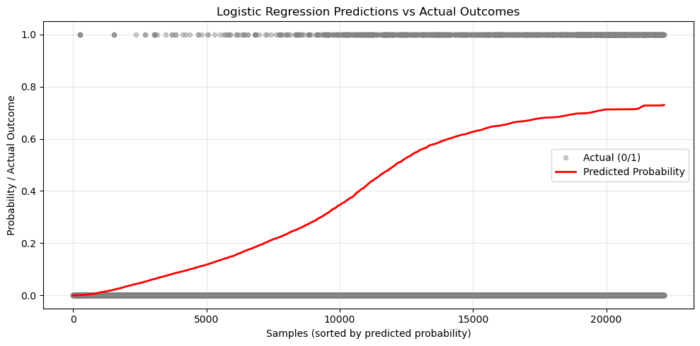

```python
plot_df = pd.DataFrame({
    "actual": y_test.values,
    "pred_prob": y_pred_prob
}).sort_values("pred_prob").reset_index(drop=True)

plt.figure(figsize=(10,5))

# Scatter actual outcomes (0 or 1)
plt.scatter(range(len(plot_df)), plot_df["actual"],
            color="gray", alpha=0.4, label="Actual (0/1)", s=20)

# Line plot of predicted probabilities
plt.plot(range(len(plot_df)), plot_df["pred_prob"],
         color="red", linewidth=2, label="Predicted Probability")

plt.title("Logistic Regression Predictions vs Actual Outcomes")
plt.xlabel("Samples (sorted by predicted probability)")
plt.ylabel("Probability / Actual Outcome")
plt.legend()
plt.grid(True, alpha=0.3)
plt.tight_layout()
plt.show()
```

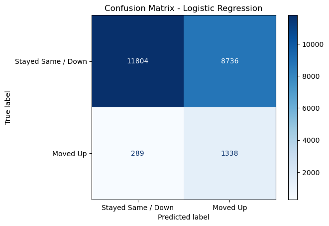

```python
# Use your existing model and test set
y_pred = pipe_lr.predict(X_test)  # predicted binary classes (0 or 1)
y_pred_prob = pipe_lr.predict_proba(X_test)[:, 1]  # predicted probabilities

# Compute confusion matrix
cm = confusion_matrix(y_test, y_pred)

# Display confusion matrix with labels based on the predicitions from the model
disp = ConfusionMatrixDisplay(confusion_matrix=cm, display_labels=["Stayed Same / Down", "Moved Up"])
disp.plot(cmap="Blues", values_format="d")
plt.title("Confusion Matrix - Logistic Regression")
plt.show()
```

# Project Summary, Takeaways, and Next Steps

These analyses show that there is moderate predictive power in customer data, such as ticket spending and game attendance, in predicting progression in a fan's engagement. In future projects, I would apply this idea to predicting fan regression, but I would also develop different models, perhaps a decision tree. I want to incorporate the domain knowledge of marketing experts to develop marketing strategies that encourage fan engagement, retention, and progression.